# Lab 5. Ch. 6 Multicategory Logit Models

Discrete Data Analysis and Lab. (326.314)

Author

Junseok Lee

Published

September 19, 2026

## Chapter 6

When a categorical response has more than two categories, its category counts are commonly modeled with a multinomial distribution. Baseline-category logit models are appropriate for nominal responses. Cumulative, adjacent-categories, and sequential logit models use the ordering of ordinal responses.

### Baseline-Category Logits

For $c$ response categories, take category $c$ as the baseline. The model is

$$\log\left(\frac{\pi_j}{\pi_c}\right)
=\alpha_j+\beta_jx,
\qquad j=1,\ldots,c-1.$$

The fitted probabilities are

$$\pi_j=
\frac{\exp(\alpha_j+\beta_jx)}
{\sum_{h=1}^c\exp(\alpha_h+\beta_hx)},$$

where $\alpha_c=\beta_c=0$. For a one-unit increase in $x$, $\exp(\beta_j)$ is the multiplicative effect on the odds of category $j$ rather than the baseline category. Changing the baseline changes the parameterization but not the fitted category probabilities.

#### Example: Alligator Food Choice

The response is the primary food type of an alligator: fish, invertebrates, or other. The explanatory variable is alligator length in meters, and `O` is used as the baseline category.

```r
Gators <- read.table(
  "https://raw.githubusercontent.com/alanagresti/categorical-data/master/Alligators.dat",
  header = TRUE
)
Gators
```

| x | y |
| --- | --- |
| 1.24 | I |
| 1.30 | I |
| 1.30 | I |
| 1.32 | F |
| 1.32 | F |
| 1.40 | F |
| 1.42 | I |
| 1.42 | F |
| 1.45 | I |
| 1.45 | O |

[output cut: 49 more lines]

```r
library(VGAM)
fit_gators <- vglm(
  y ~ x,
  family = multinomial(refLevel = "O"),
  data = Gators
)

coef(fit_gators, matrix = TRUE)
```

```
            log(mu[,1]/mu[,3]) log(mu[,2]/mu[,3])
(Intercept)           1.617731           5.697444
x                    -0.110109          -2.465446
```

```r
summary(fit_gators, hde.NA = FALSE)
```

```
Call:
vglm(formula = y ~ x, family = multinomial(refLevel = "O"), data = Gators)

Coefficients:
              Estimate Std. Error z value Pr(>|z|)
(Intercept):1   1.6177     1.3073   1.237  0.21591
(Intercept):2   5.6974     1.7937   3.176  0.00149 **
x:1            -0.1101     0.5171  -0.213  0.83137
x:2            -2.4654     0.8996  -2.741  0.00613 **
---
Signif. codes:  0 '***' 0.001 '**' 0.01 '*' 0.05 '.' 0.1 ' ' 1

Names of linear predictors: log(mu[,1]/mu[,3]), log(mu[,2]/mu[,3])

Residual deviance: 98.3412 on 114 degrees of freedom

Log-likelihood: -49.1706 on 114 degrees of freedom

Number of Fisher scoring iterations: 5


Reference group is level  3  of the response
```

The fitted equations are

$$\log\left(\frac{\hat\pi_F}{\hat\pi_O}\right)
=1.618-0.110x,$$

$$\log\left(\frac{\hat\pi_I}{\hat\pi_O}\right)
=5.697-2.465x.$$

Subtracting the second equation from the first gives

$$\log\left(\frac{\hat\pi_F}{\hat\pi_I}\right)
=-4.079+2.355x.$$

Thus, larger alligators are relatively more likely to select fish rather than invertebrates. A one-meter increase in length multiplies the estimated odds of fish rather than invertebrates by $\exp(2.355)=10.5$.

The baseline category can be changed without changing the fitted probabilities.

```r
fit_gators_invertebrate <- vglm(
  y ~ x,
  family = multinomial(refLevel = "I"),
  data = Gators
)
summary(fit_gators_invertebrate, hde.NA = FALSE)
```

```
Call:
vglm(formula = y ~ x, family = multinomial(refLevel = "I"), data = Gators)

Coefficients:
              Estimate Std. Error z value Pr(>|z|)
(Intercept):1  -4.0797     1.4686  -2.778  0.00547 **
(Intercept):2  -5.6974     1.7937  -3.176  0.00149 **
x:1             2.3553     0.8032   2.932  0.00336 **
x:2             2.4654     0.8996   2.741  0.00613 **
---
Signif. codes:  0 '***' 0.001 '**' 0.01 '*' 0.05 '.' 0.1 ' ' 1

Names of linear predictors: log(mu[,1]/mu[,2]), log(mu[,3]/mu[,2])

Residual deviance: 98.3412 on 114 degrees of freedom

Log-likelihood: -49.1706 on 114 degrees of freedom

Number of Fisher scoring iterations: 5


Reference group is level  2  of the response
```

#### Hypothesis Testing

Independence of food choice and length corresponds to

$$H_0:\beta_1=\beta_2=0.$$

A likelihood-ratio test compares the model containing length with the intercept-only model.

```r
fit_gators_null <- vglm(
  y ~ 1,
  family = multinomial(refLevel = "O"),
  data = Gators
)

lrtest(fit_gators, fit_gators_null)
```

```
Likelihood ratio test

Model 1: y ~ x
Model 2: y ~ 1
  #Df  LogLik Df  Chisq Pr(>Chisq)
1 114 -49.171
2 116 -57.571  2 16.801  0.0002248 ***
---
Signif. codes:  0 '***' 0.001 '**' 0.01 '*' 0.05 '.' 0.1 ' ' 1
```

```r
2 * (logLik(fit_gators) - logLik(fit_gators_null))
```

```
[1] 16.80061
```

The likelihood-ratio statistic is approximately 16.8 with two degrees of freedom, providing strong evidence of a length effect.

```r
fitted(fit_gators)
```

```
           F           I          O
1  0.2265307 0.721964000 0.05150528
2  0.2502564 0.692466814 0.05727683
3  0.2502564 0.692466814 0.05727683
4  0.2584591 0.682256244 0.05928463
5  0.2584591 0.682256244 0.05928463
6  0.2925882 0.639704923 0.06770685
7  0.3014156 0.628681062 0.06990334
8  0.3014156 0.628681062 0.06990334
9  0.3148464 0.611893842 0.07325976
10 0.3148464 0.611893842 0.07325976
11 0.3239142 0.600549951 0.07553586
12 0.3239142 0.600549951 0.07553586
13 0.3376640 0.583333155 0.07900282
14 0.3469154 0.571738282 0.08134629
```

[output cut: 45 more lines]

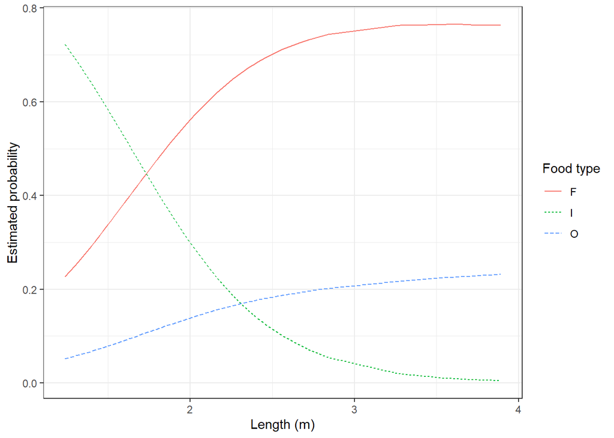

```r
gator_fitted <- data.frame(
  x = Gators$x,
  F = fitted(fit_gators)[, "F"],
  I = fitted(fit_gators)[, "I"],
  O = fitted(fit_gators)[, "O"]
)

gator_long <- tidyr::pivot_longer(
  gator_fitted,
  cols = c(F, I, O),
  names_to = "food",
  values_to = "predicted_probability"
)

ggplot2::ggplot(
  gator_long,
  ggplot2::aes(
    x = x,
    y = predicted_probability,
    color = food,
    linetype = food
  )
) +
  ggplot2::geom_line() +
  ggplot2::labs(
    x = "Length (m)",
    y = "Estimated probability",
    color = "Food type",
    linetype = "Food type"
  ) +
  ggplot2::theme_bw()
```

#### Checking Multinomial Model Goodness of Fit

For grouped multinomial data, the deviance compares the fitted model with the saturated model:

$$G^2=2\sum \text{observed}
\log\left(\frac{\text{observed}}{\text{fitted}}\right).$$

When many fitted cell counts are small, the chi-squared approximation can be unreliable. Residuals and comparisons among scientifically meaningful models should then also be examined.

#### Example: Belief in an Afterlife

The response categories are yes, undecided, and no. The predictors are gender and race, and no is the baseline category.

$$\log\left(\frac{\pi_j}{\pi_3}\right)
=\alpha_j+\beta_j^Gx_1+\beta_j^Rx_2,
\qquad j=1,2.$$

```r
Afterlife <- read.table(
  "https://raw.githubusercontent.com/alanagresti/categorical-data/master/Afterlife.dat",
  header = TRUE
)
Afterlife
```

| race | gender | yes | undecided | no |
| --- | --- | --- | --- | --- |
| white | female | 371 | 49 | 74 |
| white | male | 250 | 45 | 71 |
| black | female | 64 | 9 | 15 |
| black | male | 25 | 5 | 13 |

```r
fit_afterlife <- vglm(
  cbind(yes, undecided, no) ~ gender + race,
  family = multinomial(refLevel = "no"),
  data = Afterlife
)
summary(fit_afterlife)
```

```
Call:
vglm(formula = cbind(yes, undecided, no) ~ gender + race, family = multinomial(refLevel = "no"),
    data = Afterlife)

Coefficients:
              Estimate Std. Error z value Pr(>|z|)
(Intercept):1   1.3016     0.2265   5.747  9.1e-09 ***
(Intercept):2  -0.6529     0.3405  -1.918   0.0551 .
gendermale:1   -0.4186     0.1713  -2.444   0.0145 *
gendermale:2   -0.1051     0.2465  -0.426   0.6700
racewhite:1     0.3418     0.2370   1.442   0.1493
racewhite:2     0.2710     0.3541   0.765   0.4442
---
Signif. codes:  0 '***' 0.001 '**' 0.01 '*' 0.05 '.' 0.1 ' ' 1

Names of linear predictors: log(mu[,1]/mu[,3]), log(mu[,2]/mu[,3])

Residual deviance: 0.8539 on 2 degrees of freedom

Log-likelihood: -19.7324 on 2 degrees of freedom

Number of Fisher scoring iterations: 3


Reference group is level  3  of the response
```

To test the gender effect,

$$H_0:\beta_1^G=\beta_2^G=0.$$

```r
fit_afterlife_race <- vglm(
  cbind(yes, undecided, no) ~ race,
  family = multinomial(refLevel = "no"),
  data = Afterlife
)

lrtest(fit_afterlife, fit_afterlife_race)
```

```
Likelihood ratio test

Model 1: cbind(yes, undecided, no) ~ gender + race
Model 2: cbind(yes, undecided, no) ~ race
  #Df  LogLik Df  Chisq Pr(>Chisq)
1   2 -19.732
2   4 -23.329  2 7.1926    0.02742 *
---
Signif. codes:  0 '***' 0.001 '**' 0.01 '*' 0.05 '.' 0.1 ' ' 1
```

The likelihood-ratio statistic is approximately 7.19 with two degrees of freedom. The fitted model indicates that males are less likely than females to report belief in an afterlife, controlling for race.

```r
data.frame(
  race = Afterlife$race,
  gender = Afterlife$gender,
  fitted(fit_afterlife)
)
```

|  | race | gender | yes | undecided | no |
| --- | --- | --- | --- | --- | --- |
| 1 | white | female | 0.7545608 | 0.09956287 | 0.1458763 |
| 2 | white | male | 0.6782703 | 0.12244794 | 0.1992817 |
| 3 | black | female | 0.7073517 | 0.10018119 | 0.1924671 |
| 4 | black | male | 0.6221640 | 0.12055943 | 0.2572766 |

### Cumulative Logit Models for Ordinal Responses

For ordered response categories, define

$$P(Y\le j)=\sum_{h=1}^j\pi_h,
\qquad j=1,\ldots,c-1.$$

A cumulative logit model is

$$\operatorname{logit}\{P(Y\le j)\}
=\alpha_j+\beta_jx,
\qquad j=1,\ldots,c-1.$$

Each logit compares category $j$ or below with categories above $j$. The proportional odds model imposes a common slope,

$$\operatorname{logit}\{P(Y\le j)\}
=\alpha_j+\beta x.$$

Then $\exp(\beta)$ is a common cumulative odds ratio. Its interpretation depends on the ordering of the response categories and the direction of the cumulative probabilities.

#### Example: Political Ideology and Party Affiliation

Political ideology has five ordered categories, from liberal to conservative. The predictors are party affiliation and gender.

```r
Polviews <- read.table(
  "https://raw.githubusercontent.com/alanagresti/categorical-data/master/Polviews.dat",
  header = TRUE
)
Polviews$party <- factor(Polviews$party, levels = c("dem", "repub"))
Polviews$gender <- factor(Polviews$gender, levels = c("female", "male"))
Polviews
```

| gender | party | y1 | y2 | y3 | y4 | y5 |
| --- | --- | --- | --- | --- | --- | --- |
| female | dem | 25 | 105 | 86 | 28 | 4 |
| female | repub | 0 | 5 | 15 | 83 | 32 |
| male | dem | 20 | 73 | 43 | 20 | 3 |
| male | repub | 0 | 1 | 14 | 72 | 32 |

```r
fit_polviews <- vglm(
  cbind(y1, y2, y3, y4, y5) ~ party + gender,
  family = cumulative(parallel = TRUE, reverse = FALSE),
  data = Polviews
)
summary(fit_polviews)
```

```
Call:
vglm(formula = cbind(y1, y2, y3, y4, y5) ~ party + gender, family = cumulative(parallel = TRUE,
    reverse = FALSE), data = Polviews)

Coefficients:
              Estimate Std. Error z value Pr(>|z|)
(Intercept):1 -2.12233    0.16875 -12.577   <2e-16 ***
(Intercept):2  0.16892    0.11481   1.471    0.141
(Intercept):3  1.85716    0.15103  12.297   <2e-16 ***
(Intercept):4  4.65005    0.23496  19.791   <2e-16 ***
partyrepub    -3.63366    0.21785 -16.680   <2e-16 ***
gendermale     0.04731    0.14955   0.316    0.752
---
Signif. codes:  0 '***' 0.001 '**' 0.01 '*' 0.05 '.' 0.1 ' ' 1

Names of linear predictors: logitlink(P[Y<=1]), logitlink(P[Y<=2]),
logitlink(P[Y<=3]), logitlink(P[Y<=4])

Residual deviance: 9.8072 on 10 degrees of freedom

Log-likelihood: -35.2032 on 10 degrees of freedom

Number of Fisher scoring iterations: 4


Exponentiated coefficients:
partyrepub gendermale
0.02641936 1.04844945
```

With five response categories, the model has four intercepts. The estimated coefficient for Republicans relative to Democrats is approximately $-3.634$ with a standard error of 0.218. For every cutoff $j$, the fitted cumulative odds of being in category $j$ or below rather than above $j$ are

$$\exp(-3.634)=0.0264$$

times as high for Republicans as for Democrats. Equivalently, the fitted odds in the conservative direction are approximately $\exp(3.634)=37.9$ times as high for Republicans.

```r
data.frame(
  gender = Polviews$gender,
  party = Polviews$party,
  fitted(fit_polviews)
)
```

|  | gender | party | y1 | y2 | y3 | y4 | y5 |
| --- | --- | --- | --- | --- | --- | --- | --- |
| 1 | female | dem | 0.106945695 | 0.43518307 | 0.3228363 | 0.1255644 | 0.009470552 |
| 2 | female | repub | 0.003153813 | 0.02717842 | 0.1144033 | 0.5895341 | 0.265730342 |
| 3 | male | dem | 0.111549168 | 0.44229817 | 0.3165490 | 0.1205668 | 0.009036867 |
| 4 | male | repub | 0.003306108 | 0.02844904 | 0.1189361 | 0.5927070 | 0.256601745 |

#### Inference about Cumulative Logit Parameters

The significance of a predictor and the proportional odds assumption are separate questions. A predictor effect is tested by comparing models with and without that predictor. The proportional odds assumption is checked by comparing a common-slope model with a model that permits different slopes across cutoffs.

To test the party effect,

$$H_0:\beta_{\text{party}}=0.$$

```r
fit_polviews_gender <- vglm(
  cbind(y1, y2, y3, y4, y5) ~ gender,
  family = cumulative(parallel = TRUE, reverse = FALSE),
  data = Polviews
)

lrtest(fit_polviews, fit_polviews_gender)
```

```
Likelihood ratio test

Model 1: cbind(y1, y2, y3, y4, y5) ~ party + gender
Model 2: cbind(y1, y2, y3, y4, y5) ~ gender
  #Df   LogLik Df  Chisq Pr(>Chisq)
1  10  -35.203
2  11 -236.827  1 403.25  < 2.2e-16 ***
---
Signif. codes:  0 '***' 0.001 '**' 0.01 '*' 0.05 '.' 0.1 ' ' 1
```

```r
confint(fit_polviews, method = "profile")
```

```
                    2.5 %     97.5 %
(Intercept):1 -2.46596771 -1.8014863
(Intercept):2 -0.05464962  0.3937706
(Intercept):3  1.56835767  2.1616181
(Intercept):4  4.20347943  5.1226824
partyrepub    -4.07163810 -3.2178566
gendermale    -0.24638939  0.3414038
```

The likelihood-ratio statistic is approximately 403.25 with one degree of freedom. A 95% profile likelihood confidence interval for the cumulative odds ratio in the conservative direction is approximately $(24.98,58.67)$. The party effect is large in practical terms as well as highly significant statistically.

#### Example: Happiness and Family Income

Happiness has three ordered categories from not too happy to very happy. Family income is scored 1, 2, and 3.

```r
Happy <- read.table(
  "https://raw.githubusercontent.com/alanagresti/categorical-data/master/Happy.dat",
  header = TRUE
)
Happy
```

| income | y1 | y2 | y3 |
| --- | --- | --- | --- |
| 1 | 37 | 90 | 45 |
| 2 | 25 | 93 | 56 |
| 3 | 6 | 18 | 13 |

A proportional odds model uses one income coefficient.

```r
fit_happy_po <- vglm(
  cbind(y1, y2, y3) ~ income,
  family = cumulative(parallel = TRUE, reverse = FALSE),
  data = Happy
)

fit_happy_po_null <- vglm(
  cbind(y1, y2, y3) ~ 1,
  family = cumulative(parallel = TRUE, reverse = FALSE),
  data = Happy
)

summary(fit_happy_po)
```

```
Call:
vglm(formula = cbind(y1, y2, y3) ~ income, family = cumulative(parallel = TRUE,
    reverse = FALSE), data = Happy)

Coefficients:
              Estimate Std. Error z value Pr(>|z|)
(Intercept):1  -1.1023     0.2754  -4.003 6.25e-05 ***
(Intercept):2   1.3048     0.2775   4.701 2.59e-06 ***
income         -0.2668     0.1510  -1.768   0.0771 .
---
Signif. codes:  0 '***' 0.001 '**' 0.01 '*' 0.05 '.' 0.1 ' ' 1

Names of linear predictors: logitlink(P[Y<=1]), logitlink(P[Y<=2])

Residual deviance: 1.0168 on 3 degrees of freedom

Log-likelihood: -14.5664 on 3 degrees of freedom

Number of Fisher scoring iterations: 3


Exponentiated coefficients:
   income
0.7657883
```

```r
lrtest(fit_happy_po, fit_happy_po_null)
```

```
Likelihood ratio test

Model 1: cbind(y1, y2, y3) ~ income
Model 2: cbind(y1, y2, y3) ~ 1
  #Df  LogLik Df Chisq Pr(>Chisq)
1   3 -14.566
2   4 -16.121  1 3.109    0.07786 .
---
Signif. codes:  0 '***' 0.001 '**' 0.01 '*' 0.05 '.' 0.1 ' ' 1
```

The likelihood-ratio statistic is approximately 3.11 with one degree of freedom. The estimated income effect is negative, indicating that responses tend to shift toward higher happiness categories as income increases.

A baseline-category logit model can instead treat both happiness and income as nominal. This model is more flexible but uses four degrees of freedom for the income effect.

```r
fit_happy_nominal <- vglm(
  cbind(y1, y2, y3) ~ factor(income),
  family = multinomial(refLevel = "y3"),
  data = Happy
)

fit_happy_nominal_null <- vglm(
  cbind(y1, y2, y3) ~ 1,
  family = multinomial(refLevel = "y3"),
  data = Happy
)

summary(fit_happy_nominal)
```

```
Call:
vglm(formula = cbind(y1, y2, y3) ~ factor(income), family = multinomial(refLevel = "y3"),
    data = Happy)

Coefficients:
                  Estimate Std. Error z value Pr(>|z|)
(Intercept):1      -0.1957     0.2219  -0.882 0.377753
(Intercept):2       0.6931     0.1826   3.797 0.000147 ***
factor(income)2:1  -0.6107     0.3273  -1.866 0.062023 .
factor(income)2:2  -0.1859     0.2489  -0.747 0.455104
factor(income)3:1  -0.5774     0.5411  -1.067 0.285936
factor(income)3:2  -0.3677     0.4072  -0.903 0.366496
---
Signif. codes:  0 '***' 0.001 '**' 0.01 '*' 0.05 '.' 0.1 ' ' 1

Names of linear predictors: log(mu[,1]/mu[,3]), log(mu[,2]/mu[,3])

Residual deviance: -4.108e-15 on 0 degrees of freedom

Log-likelihood: -14.058 on 0 degrees of freedom

Number of Fisher scoring iterations: 4


Reference group is level  3  of the response
```

```r
lrtest(fit_happy_nominal, fit_happy_nominal_null)
```

```
Likelihood ratio test

Model 1: cbind(y1, y2, y3) ~ factor(income)
Model 2: cbind(y1, y2, y3) ~ 1
  #Df  LogLik Df  Chisq Pr(>Chisq)
1   0 -14.058
2   4 -16.121  4 4.1258     0.3892
```

The likelihood-ratio statistic is approximately 4.13 with four degrees of freedom. The cumulative model has greater power for detecting an ordered trend when its simpler structure is reasonable.

If income is entered quantitatively in a baseline-category model, each nonbaseline response logit has its own linear income effect.

```r
fit_happy_nominal_scores <- vglm(
  cbind(y1, y2, y3) ~ income,
  family = multinomial(refLevel = "y3"),
  data = Happy
)

lrtest(fit_happy_nominal_scores, fit_happy_nominal_null)
```

```
Likelihood ratio test

Model 1: cbind(y1, y2, y3) ~ income
Model 2: cbind(y1, y2, y3) ~ 1
  #Df  LogLik Df  Chisq Pr(>Chisq)
1   2 -14.536
2   4 -16.121  2 3.1691      0.205
```

### Cumulative Logit Model without Proportional Odds

A nonproportional odds model allows a separate predictor effect at each cumulative cutoff. It is more flexible but uses more parameters. A likelihood-ratio comparison with the proportional odds model tests the common-slope restriction.

```r
fit_polviews_nonparallel <- vglm(
  cbind(y1, y2, y3, y4, y5) ~ party + gender,
  family = cumulative(parallel = FALSE, reverse = FALSE),
  data = Polviews
)

lrtest(fit_polviews_nonparallel, fit_polviews)
```

```
Likelihood ratio test

Model 1: cbind(y1, y2, y3, y4, y5) ~ party + gender
Model 2: cbind(y1, y2, y3, y4, y5) ~ party + gender
  #Df  LogLik Df  Chisq Pr(>Chisq)
1   4 -32.093
2  10 -35.203  6 6.2211     0.3989
```

The likelihood-ratio statistic is approximately 6.22 with six degrees of freedom, so the proportional odds model is adequate for these data. Because some party-by-response cells are zero, estimates from the nonparallel model should still be checked for numerical instability.

### Interpreting Effects with Fitted Probabilities

When cumulative odds ratios are difficult to communicate, fitted probabilities can be compared at specified covariate values. The values at which the remaining covariates are held fixed should be reported.

#### Example: Modeling Mental Impairment

The response has four ordered categories from well to impaired. The predictors are the number and severity of important life events and socioeconomic status (`ses`, with 1 for high and 0 for low). The `polr()` parameterization is

$$\operatorname{logit}\{P(Y\le j)\}
=\zeta_j-\beta_1\text{life}-\beta_2\text{ses}.$$

```r
Mental <- read.table(
  "https://raw.githubusercontent.com/alanagresti/categorical-data/master/Mental.dat",
  header = TRUE
)
Mental$impair_ordered <- ordered(
  Mental$impair,
  levels = sort(unique(Mental$impair))
)
Mental
```

| impair | ses | life | impair_ordered |
| --- | --- | --- | --- |
| 1 | 1 | 1 | 1 |
| 1 | 1 | 9 | 1 |
| 1 | 1 | 0 | 1 |
| 1 | 1 | 4 | 1 |
| 1 | 1 | 3 | 1 |
| 1 | 0 | 2 | 1 |
| 1 | 0 | 1 | 1 |
| 1 | 1 | 3 | 1 |
| 1 | 1 | 3 | 1 |
| 1 | 1 | 7 | 1 |

[output cut: 30 more lines]

```r
fit_mental <- MASS::polr(
  impair_ordered ~ life + ses,
  method = "logistic",
  Hess = TRUE,
  data = Mental
)
summary(fit_mental)
```

```
Call:
MASS::polr(formula = impair_ordered ~ life + ses, data = Mental,
    Hess = TRUE, method = "logistic")

Coefficients:
       Value Std. Error t value
life  0.3189     0.1210   2.635
ses  -1.1112     0.6109  -1.819

Intercepts:
    Value   Std. Error t value
1|2 -0.2819  0.6423    -0.4389
2|3  1.2128  0.6607     1.8357
3|4  2.2094  0.7210     3.0644

Residual Deviance: 99.0979
AIC: 109.0979
```

The estimated `ses` coefficient is approximately $-1.11$, indicating that high socioeconomic status shifts the fitted distribution toward lower impairment categories.

```r
predict(
  fit_mental,
  data.frame(ses = 0, life = mean(Mental$life)),
  type = "probs"
)
```

```
        1         2         3         4
0.1617811 0.3007047 0.2372921 0.3002222
```

```r
predict(
  fit_mental,
  data.frame(ses = 1, life = mean(Mental$life)),
  type = "probs"
)
```

```
        1         2         3         4
0.3696301 0.3536702 0.1529587 0.1237410
```

At the mean number of life events, the fitted probability of the impaired category is approximately 0.300 for low SES and 0.124 for high SES.

```r
predict(
  fit_mental,
  data.frame(ses = 0, life = min(Mental$life)),
  type = "probs"
)
```

```
         1          2          3          4
0.42998727 0.34080542 0.13029529 0.09891202
```

```r
predict(
  fit_mental,
  data.frame(ses = 0, life = max(Mental$life)),
  type = "probs"
)
```

```
         1          2          3          4
0.04102612 0.11914448 0.18048372 0.65934567
```

```r
predict(
  fit_mental,
  data.frame(ses = 1, life = min(Mental$life)),
  type = "probs"
)
```

```
         1          2          3          4
0.69621280 0.21463441 0.05428168 0.03487110
```

```r
predict(
  fit_mental,
  data.frame(ses = 1, life = max(Mental$life)),
  type = "probs"
)
```

```
        1         2         3         4
0.1150236 0.2518325 0.2439856 0.3891584
```

For low SES, the fitted probability of the impaired category rises substantially as life events increase from their minimum to maximum values.

### Cumulative Probit Model

The cumulative probit model uses the probit link for the cumulative probabilities. It applies when an underlying latent variable has a normal distribution with constant variance.

```r
Polviews2 <- read.table(
  "https://raw.githubusercontent.com/alanagresti/categorical-data/master/Polviews2.dat",
  header = TRUE
)
Polviews2$ideology_ordered <- ordered(Polviews2$ideology, levels = 1:5)
Polviews2$party <- factor(Polviews2$party, levels = c("dem", "repub"))
Polviews2$gender <- factor(Polviews2$gender, levels = c("female", "male"))
```

```r
fit_polviews_probit <- MASS::polr(
  ideology_ordered ~ party + gender,
  method = "probit",
  Hess = TRUE,
  data = Polviews2
)
summary(fit_polviews_probit)
```

```
Call:
MASS::polr(formula = ideology_ordered ~ party + gender, data = Polviews2,
    Hess = TRUE, method = "probit")

Coefficients:
               Value Std. Error  t value
partyrepub  2.032496    0.10996 18.48406
gendermale -0.007489    0.08562 -0.08747

Intercepts:
    Value    Std. Error t value
1|2  -1.2353   0.0890   -13.8853
2|3   0.1033   0.0694     1.4901
3|4   1.0532   0.0808    13.0376
4|5   2.6171   0.1194    21.9153

Residual Deviance: 1565.195
AIC: 1577.195
```

The estimated party coefficient is approximately 2.03. Its positive sign indicates that, controlling for gender, Republicans tend to fall in the more conservative ideology categories than Democrats.

### Paired-Category Logit Models for Ordinal Responses

#### Adjacent-Categories Logit Model

Adjacent-categories logits compare neighboring response categories:

$$\log\left(\frac{\pi_j}{\pi_{j+1}}\right),
\qquad j=1,\ldots,c-1.$$

A common-slope model is

$$\log\left(\frac{\pi_j}{\pi_{j+1}}\right)
=\alpha_j+\beta x.$$

The exponentiated coefficient is a local odds ratio. The common-slope structure assumes that the effect is the same for every adjacent pair of categories.

#### Example: Political Ideology Revisited

```r
fit_polviews_adjacent <- vglm(
  cbind(y1, y2, y3, y4, y5) ~ party + gender,
  family = acat(parallel = TRUE, reverse = TRUE),
  data = Polviews
)
summary(fit_polviews_adjacent)
```

```
Call:
vglm(formula = cbind(y1, y2, y3, y4, y5) ~ party + gender, family = acat(parallel = TRUE,
    reverse = TRUE), data = Polviews)

Coefficients:
              Estimate Std. Error z value Pr(>|z|)
(Intercept):1 -1.38707    0.17079  -8.121 4.61e-16 ***
(Intercept):2  0.36218    0.11749   3.083  0.00205 **
(Intercept):3  0.77529    0.14720   5.267 1.39e-07 ***
(Intercept):4  2.99240    0.23132  12.936  < 2e-16 ***
partyrepub    -2.23478    0.16841 -13.270  < 2e-16 ***
gendermale     0.01212    0.09661   0.125  0.90016
---
Signif. codes:  0 '***' 0.001 '**' 0.01 '*' 0.05 '.' 0.1 ' ' 1

Names of linear predictors: loglink(P[Y=1]/P[Y=2]), loglink(P[Y=2]/P[Y=3]),
loglink(P[Y=3]/P[Y=4]), loglink(P[Y=4]/P[Y=5])

Residual deviance: 13.4665 on 10 degrees of freedom

Log-likelihood: -37.0329 on 10 degrees of freedom

Number of Fisher scoring iterations: 4


Exponentiated coefficients:
partyrepub gendermale
 0.1070151  1.0121943
```

With `reverse = TRUE`, each log ratio is $\log\{P(Y=j)/P(Y=j+1)\}$. The estimated party coefficient for Republicans relative to Democrats is approximately $-2.235$. Therefore, for each adjacent pair, the fitted odds of the lower ideology category rather than the next higher category are $\exp(2.235)=9.34$ times as high for Democrats as for Republicans.

#### Sequential Logit Model

A stopping-ratio form of the sequential logits is

$$\log\left(\frac{\pi_1}{\pi_2+\cdots+\pi_c}\right),
\quad
\log\left(\frac{\pi_2}{\pi_3+\cdots+\pi_c}\right),
\quad\ldots,\quad
\log\left(\frac{\pi_{c-1}}{\pi_c}\right).$$

These models are useful when the response categories represent stages in a process. The direction of the sequence should match the scientific interpretation.

#### Example: Tonsil Size and Streptococcus

The response categories are not enlarged, enlarged, and greatly enlarged. The explanatory variable indicates whether a child is a carrier of *Streptococcus pyogenes*.

```r
Tonsils <- data.frame(
  carrier = factor(c("yes", "no"), levels = c("no", "yes")),
  y1 = c(19, 497),
  y2 = c(29, 560),
  y3 = c(24, 269)
)
Tonsils
```

| carrier | y1 | y2 | y3 |
| --- | --- | --- | --- |
| yes | 19 | 29 | 24 |
| no | 497 | 560 | 269 |

```r
fit_tonsils <- vglm(
  cbind(y1, y2, y3) ~ carrier,
  family = sratio(parallel = TRUE, reverse = FALSE),
  data = Tonsils
)
summary(fit_tonsils)
```

```
Call:
vglm(formula = cbind(y1, y2, y3) ~ carrier, family = sratio(parallel = TRUE,
    reverse = FALSE), data = Tonsils)

Coefficients:
              Estimate Std. Error z value Pr(>|z|)
(Intercept):1 -0.51102    0.05614  -9.102  < 2e-16 ***
(Intercept):2  0.73218    0.07286  10.049  < 2e-16 ***
carrieryes    -0.52846    0.19775  -2.672  0.00753 **
---
Signif. codes:  0 '***' 0.001 '**' 0.01 '*' 0.05 '.' 0.1 ' ' 1

Names of linear predictors: logitlink(P[Y=1|Y>=1]), logitlink(P[Y=2|Y>=2])

Residual deviance: 0.0057 on 1 degrees of freedom

Log-likelihood: -11.7659 on 1 degrees of freedom

Number of Fisher scoring iterations: 3


Exponentiated coefficients:
carrieryes
 0.5895113
```

The estimated carrier coefficient is approximately $-0.528$, so $\exp(-0.528)=0.59$. The model assumes this common multiplicative effect for the odds of not enlarged rather than enlarged or greatly enlarged and, among children with at least enlarged tonsils, for the odds of enlarged rather than greatly enlarged. The residual deviance is approximately 0.006 with one degree of freedom.